# 05. 행렬의 확장 개념

```python
import numpy as np
import matplotlib.pyplot as plt
import scipy.linalg
from scipy.linalg import toeplitz

import matplotlib_inline.backend_inline
plt.rcParams.update({'font.size':14})
```

## 05.01. 행렬 노름

### 행렬 노름

- 벡터 노름은 유클리드 기하학적 길이로 벡터 원소 제곱합의 제곱근으로 계산되는 반면,

  $$||v|| = \sqrt{\sum^n_{i=1} v^2_i}$$

  **행렬은 여러 개의 서로 다른 노름을 가짐**
- 각 행렬 노름은 행렬을 특정짓는 하나의 숫자라는 점에서 벡터 노름과 유사
- 각 행렬 노름은 서로 다른 의미를 가지며, 크게 원소별 (항목별) 계열과 유도(induced) 계열로 나뉘어짐

#### 행렬 노름은 행렬이 가진 숫자의 크기와 관련

- 행렬 노름은 음수가 아니며, 영 행렬에 대해서만 0이 될 수 있음

### 유도별 노름

- **행렬은 벡터를 변환하는 기능이 있으며, 유도별 노름은 이 변환으로 인해 벡터의 크기(노름)가 얼마나 조정되는지에(늘리거나 줄이거나)에 대한 측정치**

### 원소별 노름

#### 유클리드 노름 (프로베니우스 노름, Frobeniums Norm)

- 모든 행렬 원소의 제곱합이 제곱근으로 계산

$$||A||_F = \sqrt{\sum^M_{i=1} \sum^N_{j=1}a^2_{ij}}$$

- 유클리드 노름은 $p=2$일 때의 $p$-노름 ($l2$노름)

$$||A||_p = (\sum^M_{i=1} \sum^N_{j=1} |a_{ij}|^p)^{1/p}$$

#### 행렬의 대각합 (Trace)

- 행렬의 대가합 : 대각 원소의 합 ($tr(A)$)이며, 정방행렬에 대해서만 존재
- **행렬의 대각합은 행렬의 고윳값의 합과 같고, 결국 행렬의 고유공간(eigenspace)의 '부피'에 대한 측정치**
- **프로베니우스 노름은 어떤 행렬의 전치와 그 행렬을 곱한 결과의 대각합의 제곱근 (=내적 대각합의 제곱근)**

$$||A||_F = \sqrt{\sum^M_{i=1} \sum^N_{j=1}a^2_{ij}}=\sqrt{tr(A^T A)}$$

## 05.02. 행렬 공간 (열, 행, 영)

### 열공간

- **개념적으로 행렬을 열벡터의 집합으로 간주할 때,**

  **$\rightarrow$ 하나의 특정 스칼라 집합으로 연산하는 대신 실수 스칼라를 적용**

  **$\rightarrow$ 무한 개의 스칼라로 벡터 집합을 무한히 결합 가능**

  **$\rightarrow$ 이 결과로 생성된 벡터 집합이 행렬의 열공간 $C(A)$**
- **행렬에 $N$개의 열이 있다고해서 열공간이 무조건 $N$차원이 되지 않음**
- **행렬의 열공간에 벡터가 있는지 여부를 확인하기 위한 정량적 방법은 행렬 계수를 활용**

#### 수학적 표현

- **행렬 $A$의 열의 가중 결합에서, 많은 가중치 집합 $x$를 통하여 생성될 수 있는 모든 $b$의 집합 = 열공간 $C(A)$**

$$Ax=b$$

- **열이 하나만 있는 행렬 (열벡터와 동일)의 예시**
  - 해당 열의 모든 가능한 선형 가중 결합인 열공간
  - $C(A)$ : 행렬 $A$의 열공간
  - $\lambda$ : 모든 가능한 실숫값

$$C\begin{pmatrix} {\begin{bmatrix} 1\\3 \end{bmatrix}} \end{pmatrix} = \lambda \begin{bmatrix} 1\\3 \end{bmatrix},\;\;\; \lambda \in \mathbb{R}$$

- $\lambda=1$ $\rightarrow$ 벡터 $\begin{bmatrix} 1\\3 \end{bmatrix}$는 열공간에 존재
- $\lambda=-2$ $\rightarrow$ 벡터 $\begin{bmatrix} -2\\-6 \end{bmatrix}$는 열공간에 존제
- 열공간은 열벡터 방향으로 원점을 통과하는 선이 양방향으로 무한에 가깝게 뻗어나가는 형태

  (무한대는 실수가 아니기에, 무한대에 가깝게 뻗어나감)

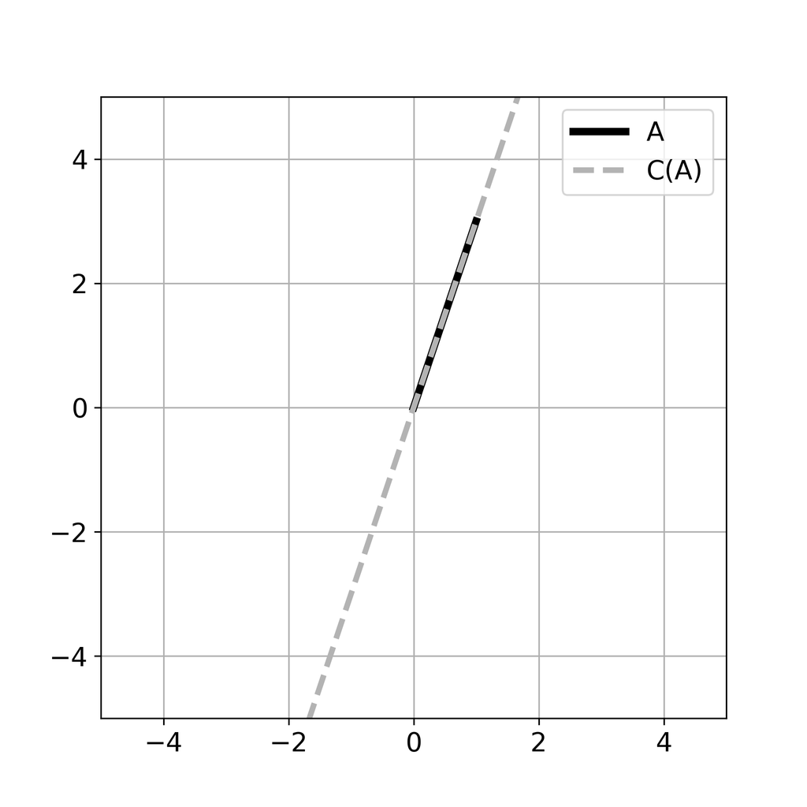

- **2개의 열을 가진 행렬 예시**
  - $A1$행렬의 열공간 $\rightarrow$ $\mathbb{R}^2$의 모든 벡터

  $$C\begin{pmatrix} {\begin{bmatrix} 1&1\\3&2 \end{bmatrix}} \end{pmatrix} = \lambda_1 \begin{bmatrix} 1\\3 \end{bmatrix}+\lambda_2 \begin{bmatrix} 1\\2 \end{bmatrix},\;\;\; \lambda \in \mathbb{R}$$
  - **반면, 아래의 $A2$행렬의 벡터 사이에는 선형 가중 결합이 존재 $\rightarrow$ 열공간의 차원은 1차원이며, $\mathbb{R}^2$의 모든 벡터가 아님**

  $$C\begin{pmatrix} {\begin{bmatrix} 1&2\\3&6 \end{bmatrix}} \end{pmatrix} = \lambda_1 \begin{bmatrix} 1\\3 \end{bmatrix}+\lambda_2 \begin{bmatrix} 2\\6 \end{bmatrix},\;\;\; \lambda \in \mathbb{R}$$

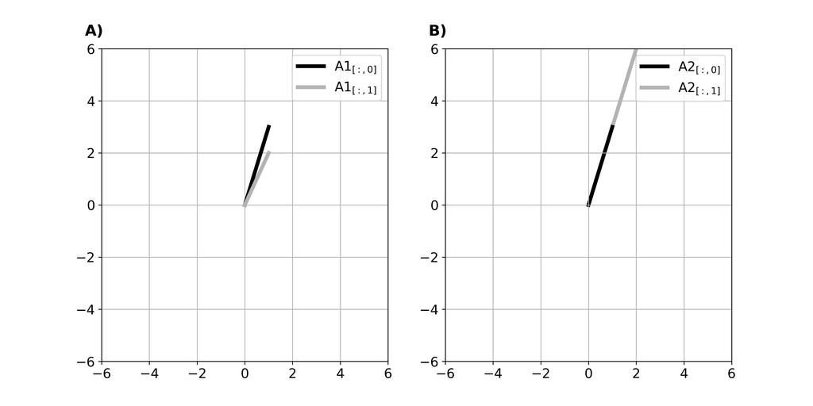

- **3개의 열을 가진 행렬 예시**
  - **$A3$행렬의 벡터 사이에는 선형 가중 결합이 없음 $\rightarrow$ 열공간은 $\mathbb{R}^3$에 포함된 2차원 평면**
  - 평면에는 많은 벡터(두 열벡터의 선형 결합으로 얻을 수 있는 벡터)가 있지만, 평면 밖에 더 많은 벡터가 존재

    즉, 행렬의 열공간에 벡터가 있고, 행렬의 열 공간 밖에 벡터가 있음

    $$C\begin{pmatrix} {\begin{bmatrix} 3&0\\5&2\\1&2 \end{bmatrix}} \end{pmatrix} = \lambda_1 \begin{bmatrix} 3\\5\\1 \end{bmatrix}+\lambda_2 \begin{bmatrix} 0\\2\\2 \end{bmatrix},\;\;\; \lambda \in \mathbb{R}$$

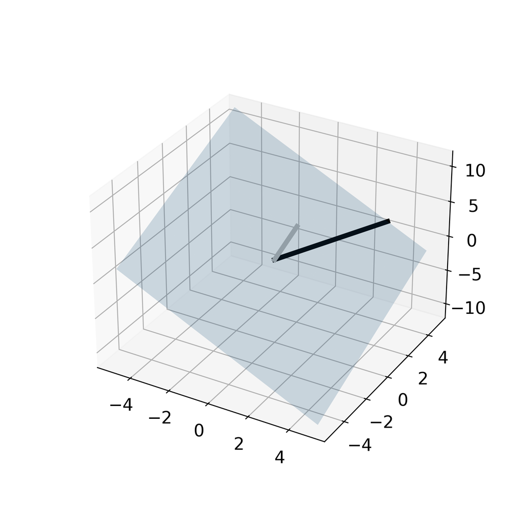

### 행공간

- **행렬을 행벡터의 집합으로 간주하여, 행으로 가능한 모든 가중 결합하여 생성한 벡터집함 $\rightarrow$ 행공간 $R(A)$**
- **행렬의 행공간은 전치된 행렬의 열공간**
  - 행렬이 대칭행렬일 때, 행공간과 열공간이 동일

$$R(A) = C(A^T)$$

- **행공간은 행 축소 연산의 변형**

### 영공간

- **행렬 $A$의 열의 가중 결합을 통하여 영벡터가 되게 하는, 가중치 집합 $y$**

$$Ay=0$$

#### 계수-영공간의 차원 정리 (nulity)

- **행렬의 열이 선형 독립 집합이라면, 영공간은 비어있음**
- **예시** $$A =\begin{bmatrix} 1&-1\\-2&2 \end{bmatrix}\;\;\;B =\begin{bmatrix} 1&-1\\-2&3 \end{bmatrix}$$
  - **$A$의 열간 선형 종속 관계 존재**
    - **$Ay=0$을 만족하는 $y$는 무한히 존재, $A$의 영공간은 아래와 같이 표현**

  $$N(A) = \lambda \begin{bmatrix} 1\\1 \end{bmatrix},\;\;\;\lambda \in \mathbb{R}$$
  - **$B$의 열간 선형 독립**
    - **$By=0$을 만족하는 $y$는 존재하지 않음. 따라서 $B$의 영공간은 아래와 같이 표현**

  $$N(B)=\{\}$$

#### `scipy.linalg.null_space()` : 행렬의 영공간 계산

- **행렬의 영공간이 무한하다면 단위벡터를 반환받음**

  $0.70711 = \sqrt{1/2}$

```python
A = np.array([ [1,-1],[-2,2] ])
B = np.array([ [1,-1],[-2,3] ])

print( scipy.linalg.null_space(A) )
print(' ')
print( scipy.linalg.null_space(B) )
```

```
[[0.70710678]
 [0.70710678]]

[]
```

#### 영공간 벡터와 각 행 사이의 내적은 0

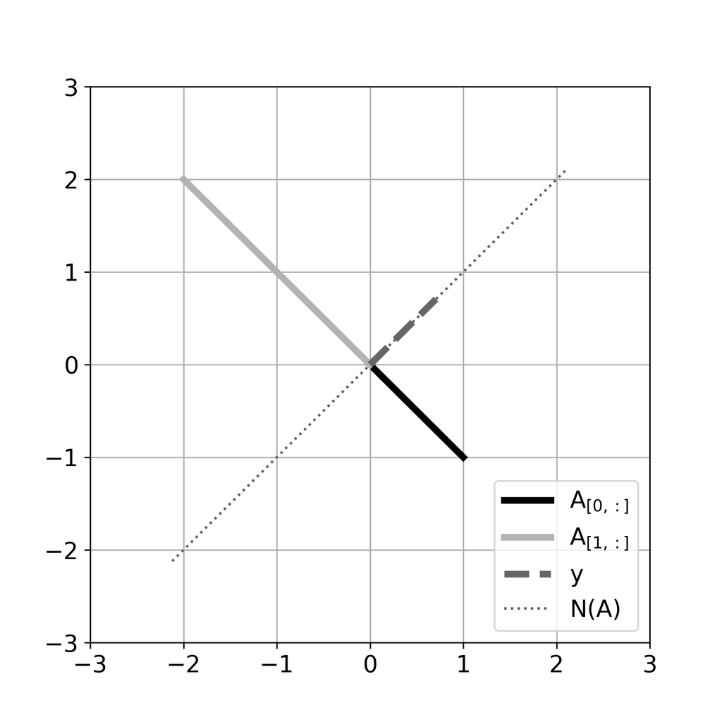

### 왼쪽 영공간

- 행의 영공간 (행렬 전치의 영공간, $N(A^T)$)

## 05.03. 계수 (Rank)

#### 행렬 계수의 속성

1. 계수는 음이 아닌 정수
2. 모든 행렬은 하나의 고유한 계수를 가짐 (서로 다른 계수를 여러 개 가질 수 없음)
3. 행렬의 계수는 $r(A)$ 또는 $rank(A)$로 표현 ($A$는 '계수-$r$ 행렬')
4. 행렬의 최대로 가능한 계수는 행 또는 열의 개수 중에서 더 작은 값, 즉 $r=min(M,N)$이 되는 행렬
5. 최대로 가능한 계수를 갖는 행렬은 '최대계수'(전계수, full rank)
6. 계수가 $r < min(M, N)$인 행렬은 '축소계수' ('계수부족', '특이')
7. **스칼라 곱셈은 행렬 계수에 영향을 미치지 않음 (0 제외)**

#### 행렬 계수에 대한 해석과 정의

1. **선형 독립 집합을 형성하는 최대 열(또는 행)의 수**
2. 열공간의 차원의 수(행공간의 차원의 수와 동일)
3. **행렬 안의 정보를 포함하는 고유 차원 수, (선형 종속적일 가능성이 있으므로, 행렬의 전체 열 또는 행 수와 같지 않음)**
4. **행렬에서 0이 아닌 특잇값의 수**

#### 행렬 계수의 계산

$$\begin{bmatrix} 1&1&-4\\2&-2&2 \end{bmatrix}$$

- 행렬의 세 열은 선형 종속 $\rightarrow$ 열공간은 $\mathbb{R}^2$의 2차원
- 행렬의 두 행은 선형 독림 $\rightarrow$ 행공간은 $\mathbb{R}^3$의 2차원

  **$\rightarrow$ 행렬의 열공간과 행공간이 다르지만, 행렬 공간의 차원의 수는 동일**

  **$\rightarrow$ 행렬의 계수는 2**
- **영행렬의 계수는 0**

$$F=\begin{bmatrix} 0&0&0\\0&0&0\\0&0&0 \end{bmatrix}$$$$rank(F) = 0$$

### 특수 행렬의 계수

#### 벡터

- **모든 벡터의 계수는 1**
- 정의상으로 벡터는 정보의 열(또는 행)이 1개밖에 없기 때문
- 벡터가 생성하는 부분공간은 1차원
- **영벡터는 예외**

#### 영 행렬

- **모든 영 행렬(영벡터 포함)의 계수는 0**

#### 단위 행렬

- **단위 행렬의 계수는 행의 수(열의 수)와 동일**

$$r(I_N)=N$$

#### 대각 행렬

- **대각 행렬의 계수는 0이 아닌 대각 원소의 수**

#### 삼각 행렬

- **삼각 행렬은 모든 대각선 원소에 0이 아닌 값이 있는 경우에만 최대계수**
- **대각선에 0이 하나 이상 있는 삼각 행렬은 축소계수**

#### 계수-1 행렬

- **계수-1 행렬은 정방이거나 높거나 넓을 수 있음**
- **0이 아닌 두 벡터 사이에서 외적을 취함 $\rightarrow$ 계수-1 행렬**

$$\begin{bmatrix} 4\\2\\3 \end{bmatrix} \begin{bmatrix} 3&1&1&3&1 \end{bmatrix} = \begin{bmatrix} 12&4&4&12&4\\6&2&2&6&2\\9&3&3&9&3 \end{bmatrix}$$

### 덧셈 및 곱셈 행렬의 계수

- 개별 행렬의 계수를 알고 있다고 해서, 덧셈 행렬 또는 곱 행렬의 정확한 계수를 알 수 없음 (영 행렬 제외)

$$rank(A+B) \leq rank(A) + rank(B)$$$$rank(AB) \leq min\{rank(A), rank(B)\}$$

### 이동된 행렬의 계수

- **행렬을 이동시키면, 행렬의 계수가 증가할 수 있음**
- 예시
  - **왼 쪽 행렬의 계수는 2, 단위행렬을 더한 결과, 행렬의 계수는 3**

    **그러나, 행렬이 가진 정보는 거의 변하지 않음**

    **원래 행렬과 이동 행렬의 원소 사이의 피어슨 상관계수 $\rho=0.9999$**
  - **기존 계수-2행렬은 가역(역행렬이 존재)이 아니었지만, 이동된 행렬은 가역**

#### `np.linalg.matrix_rank()`

```python
A = np.array([[1, 3, 2], [5, 7, 2], [2, 2, 0]])
B = A + 0.1*np.eye(3)

print('rank(A)')
print(np.linalg.matrix_rank(A), '\n')

print('rank(B)')
print(np.linalg.matrix_rank(B))
```

```
rank(A)
2

rank(B)
3
```

### 벡터의 열공간 존재 여부

#### 확장 (augmenting)

- 행렬의 오른쪽에 열을 추가

$$\begin{bmatrix} 4&5&6\\0&1&2\\9&9&4 \end{bmatrix} \sqcup \begin{bmatrix} 1\\2\\3 \end{bmatrix} = \begin{bmatrix} 4&5&6&1\\0&1&2&2\\9&9&4&3 \end{bmatrix}$$

#### 벡터가 행렬의 열공간에 포함되어있는지 확인

1. 벡터로 행렬을 확장 : $A$ $\rightarrow$ $\tilde{A}$
2. 두 행렬의 계수를 계산
3. 두 행렬의 계수를 비교
   - $rank(A) = rank(\tilde{A})$ : 벡터는 행렬 $A$의 열공간에 존재
   - $rank(A) < rank(\tilde{A})$ : 벡터는 행렬 $A$의 열공간에 없음
- 벡터($v$)가 $\in C(A)$라면, $v$는 $A$의 열들의 선형 가중 결합으로 나타낼 수 있음 $\rightarrow$ $\tilde{A}$의 열들은 선형 종속 집합이 됨

  생성 측면에서 $v$는 $\tilde{A}$에서 중복
- $v \notin C(A)$라면, $v$는 $A$의 열들의 선형 가중 결합으로 나타낼 수 없으며, $v$가 $\tilde{A}$에 새운 정보를 추가했다는 뜻

  $\rightarrow$ 계수가 1만큼 증가

## 05.05. 행렬식

- **정방 행렬에 대해서만 정의되며, 특이(축소계수) 행렬에 대해서는 0**
- $det(A)$ 또는 $|A|$로 표현

### 행렬식 계산

- 행렬식은 정수나 양수에 국한되지 않음
- $2 \times 2$행렬의 행렬식

$$det\begin{pmatrix} {\begin{bmatrix} a&b\\c&d \end{bmatrix}} \end{pmatrix} = \begin{vmatrix}a&b\\c&d\end{vmatrix} = ad-bc$$

- $3 \times 3$행렬의 행렬식

$$\begin{vmatrix} a&b&c\\d&e&f\\g&h&i \end{vmatrix} = aei + bfg + cdh-ceg-bdi-afh$$

- $4 \times 4$행렬의 행렬식

$$\begin{vmatrix} a&b&c&d\\e&f&g&h\\i&j&k&l\\m&n&o&p \end{vmatrix} = afkp-aflo-agjp+agln+ahjo-ahkn-bekp+belo+bgip-bglm-bhio+bhkm+cejp-celn-celn-cfip+cflm+chin-chjm-dejo+dekn+dfio-dfkm-dgin+dgjm$$

### 선형 종속성과 행렬식

#### 모든 축소계수 행렬의 행렬식은 0

- $r < M$이라면 $\Delta = 0$

#### 모든 최대계수 행렬의 행렬식은 0이 아님

$$\begin{vmatrix} a&\lambda a\\c&\lambda c \end{vmatrix} = ac\lambda - a\lambda c = 0$$

### 특성 다항식 (characteristic polynomial)

- 수학적 방식으로, 행렬 내부의 알려지지 않은 원소를 계산
- **행렬식의 해를 0으로 놓음으로서, 해당 행렬의 계수를 1로 만드는 수를 계산하며,**

  **영공간을 만족시키는 0이 아닌 벡터를 찾을 수 있음**

$$det(A-\lambda I) = \Delta=0$$

#### 최대계수 행렬 예시

- $\lambda$가 미지수라고 가정할 때,

$$det\begin{pmatrix} \begin{bmatrix} 1&3\\3&1 \end{bmatrix} - \lambda I \end{pmatrix} = 0$$$$\begin{vmatrix} 1-\lambda&3\\3&1-\lambda \end{vmatrix} =0\;\;\;\rightarrow\;\;\;(1-\lambda)^2-9=0$$

- 이동된 $M \times M$행렬은 $\lambda ^M$항을 가지며, $M$개의 해가 존재

$$\lambda = -2\;or\;4$$

- 특성 다항식의 해를 대입 $\rightarrow$ 대입한 행렬의 계수는 모두 1
- 대입한 행렬 $(A-\lambda I)y=0$을 만족하는 0이 아닌 벡터 $y$를 찾을 수 있음

$$\lambda = -2 \;\;\;\rightarrow\;\;\; \begin{bmatrix} 3&3\\3&3 \end{bmatrix}$$$$\lambda = 4 \;\;\;\rightarrow\;\;\; \begin{bmatrix} -3&3\\3&-3 \end{bmatrix}$$